# B cell modelling

## Martinez model

This is the first model by Martinez et al. displaying the interaction between Blimp1, Bcl6 and Irf4 and showing the effects of BCR and CD40 signalling.

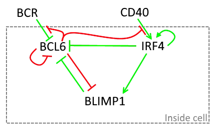

Equation 1: Blimp-1 expression

$$\frac{d[Blimp1]}{dt}=\mu_{blimp}+\sigma_{blimp}*\frac{k_{bcl}^2}{k_{bcl}^2+[Bcl6]^2}+\sigma_{blimp}*\frac{[Irf4]^2}{k_{irf}^2+[Irf4]^2} - \lambda_{blimp}*[Blimp1]$$
Equation 2: Bcl6 expression
$$\frac{d[Bcl6]}{dt}=\mu_{bcl}+\sigma_{bcl}*\frac{k_{blimp}^2}{k_{blimp}^2+[Blimp1]^2}*\frac{k_{bcl}^2}{k_{bcl}^2+[Bcl6]^2}*\frac{k_{irf}^2}{k_{irf}^2+[Irf4]^2}-(\lambda_{bcl} + BCR)*[Bcl6]$$
Equation 3: Irf4 expression
$$\frac{d[Irf4]}{dt}=\mu_{irf}+\sigma_{irf}*\frac{[Irf4]^2}{k_{irf}^2+[Irf4]^2}+CD40-\lambda_{irf}*[Irf4]$$

```r
library("ggplot2")
library("dplyr")
library("deSolve")
library('tidyr')
library('directlabels')

Martinez1 <- function(t, y, parameters) {
  #calculates dx/dts for a GRN

  # t: time at which to evaluate derivatives
  # y: vector of system variables (c(P,B,R))
  # parameters: vector of model parameters

  BLIMP1 <- y[1]
  BCL6 <- y[2]
  IRF4 <- y[3]

  up <- parameters['up']    # passive transcription rate
  ub <- parameters['ub']
  ur <- parameters['ur']

  op <- parameters['op']    # max induced transcription rate
  ob <- parameters['ob']
  or <- parameters['or']

  kb <- parameters['kb']    # dissociation constant
  kr <- parameters['kr']
  kp <- parameters['kp']

  ep <- parameters['ep']    # rate of degradation
  eb <- parameters['eb']
  er <- parameters['er']

  CD40 <-2 * dnorm(t, 25, 2) * (kb ^ 2 / (kb ^ 2 + BCL6 ^ 2))
  BCR <- 20 * dnorm(t, 21, 2) * (kb ^ 2 / ( kb ^ 2 + BCL6 ^ 2))

  # calculate rate of change
  dBLIMP1 <- up + op * (kb ^ 2 / (kb ^ 2 + BCL6 ^ 2)) + op * (IRF4 ^ 2 / (kr ^ 2 + IRF4 ^ 2)) - ep * BLIMP1
  dBCL6 <- ub + ob * (kp ^ 2 / (kp ^ 2 + BLIMP1 ^ 2)) * (kb ^ 2 / (kb ^ 2 + BCL6 ^ 2)) * (kr ^ 2 / (kr ^ 2 + IRF4 ^ 2)) - (eb + BCR) * BCL6
  dIRF4 <- ur + or * (IRF4 ^ 2 / (kr ^ 2 + IRF4 ^ 2)) + CD40 - er * IRF4

  # return rate of change
  return(list(c(dBLIMP1, dBCL6, dIRF4)))
}

# run the numerical solution

parameters = c(
  up = 10 ^ -6,
  ub = 2,
  ur = 0.1,
  op = 9,
  ob = 100,       #just some parameters, no bxiggie
  or = 2.6,
  kp = 1,
  kb = 1,
  kr = 1,
  ep = 1,
  eb = 1,
  er = 1,
  BCR = 0,
  CD40 = 0
)

state <- c(BLIMP1 = 0.735, BCL6 = 4.7, IRF4 = 0.2) # starting states

times <- seq(0, 50, by = 0.01)

result <- ode(y=state, times = times, func = Martinez1, parms = parameters)
result <- data.frame(result)

result <- mutate(result, BCR = dnorm(time, 21, 2) * 150 * (1 / ( 1 + BCL6 ^ 2))) %>%
  mutate(CD40 = dnorm(time, 25, 2)* 150 * (1 / ( 1 + BCL6 ^ 2)))

result <- result %>%
  gather(Factor, Value, -time)
str(result)
```

```
## 'data.frame':    25005 obs. of  3 variables:
##  $ time  : num  0 0.01 0.02 0.03 0.04 0.05 0.06 0.07 0.08 0.09 ...
##  $ Factor: chr  "BLIMP1" "BLIMP1" "BLIMP1" "BLIMP1" ...
##  $ Value : num  0.735 0.735 0.735 0.735 0.735 ...
```

```r
result$Factor <- factor(result$Factor, levels = c("BLIMP1", "BCL6", "IRF4", "BCR", "CD40"))
str(result)
```

```
## 'data.frame':    25005 obs. of  3 variables:
##  $ time  : num  0 0.01 0.02 0.03 0.04 0.05 0.06 0.07 0.08 0.09 ...
##  $ Factor: Factor w/ 5 levels "BLIMP1","BCL6",..: 1 1 1 1 1 1 1 1 1 1 ...
##  $ Value : num  0.735 0.735 0.735 0.735 0.735 ...
```

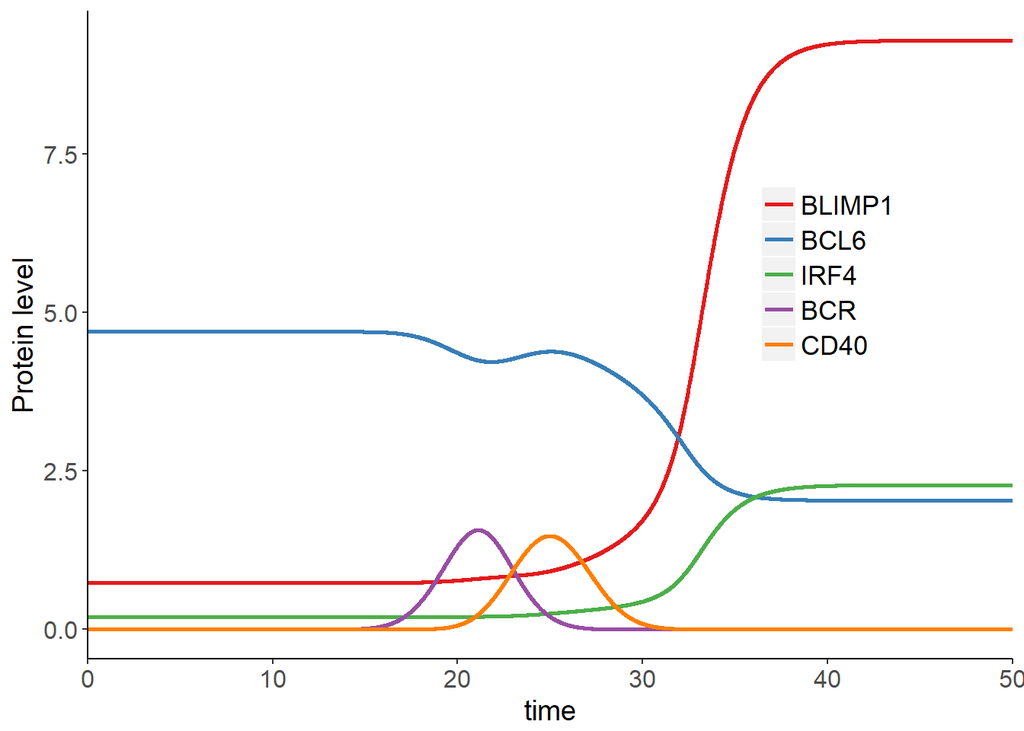

```r
# plot the results

result %>%
  ggplot(aes(x=time, y= Value,fill = Factor, color = Factor)) +
  geom_line(aes(x = time, y = Value), cex = 1) +
  scale_color_brewer(palette = "Set1")+
  theme(panel.background = element_rect(fill = "white")) +
  theme(plot.title = element_text(size = 12, face = "bold"),
    legend.title=element_text(size=14),
    legend.text=element_text(size=13))+
  scale_x_continuous(expand = c(0, 0)) +
  theme(legend.position=c(0.8,0.6), legend.title = element_blank(), axis.line = element_line(colour = "black"))+
  labs(y = "Protein level", x= "time",cex=5) +
  theme(axis.text=element_text(size=12), axis.title=element_text(size=14))
```

## Muto

The model formulated by Muto et al. is shown below. The model involves 3 main transcription factors: Bach2 Pax5 and Blimp-1. Pax5 and Blimp-1 have a mutual respression and Bach is hypothesized to act as a regulator.

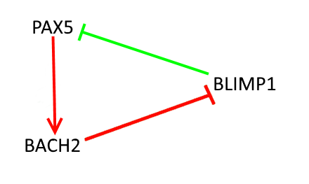

Equation 1
$$\frac{d[Pax5]}{dt}=\frac{C_1}{1+C_2[Blimp\text{-}1]^{n_s}} + e_0-[Pax5]$$
Equation 2
$$\frac{\mathrm{d}[Bach2]}{\mathrm{d}t}=\left[\frac{C_3}{1+C_4[Blimp\text{-}1]^{n_\text{s'}}}\right]\left[\frac{a_1[Pax5]}{1+b_1[Pax5]^{n_r}} + e_1 \right] - [Bach2]$$
Equation 3
$$[Blimp\text{-}1] = c/[Bach2]$$

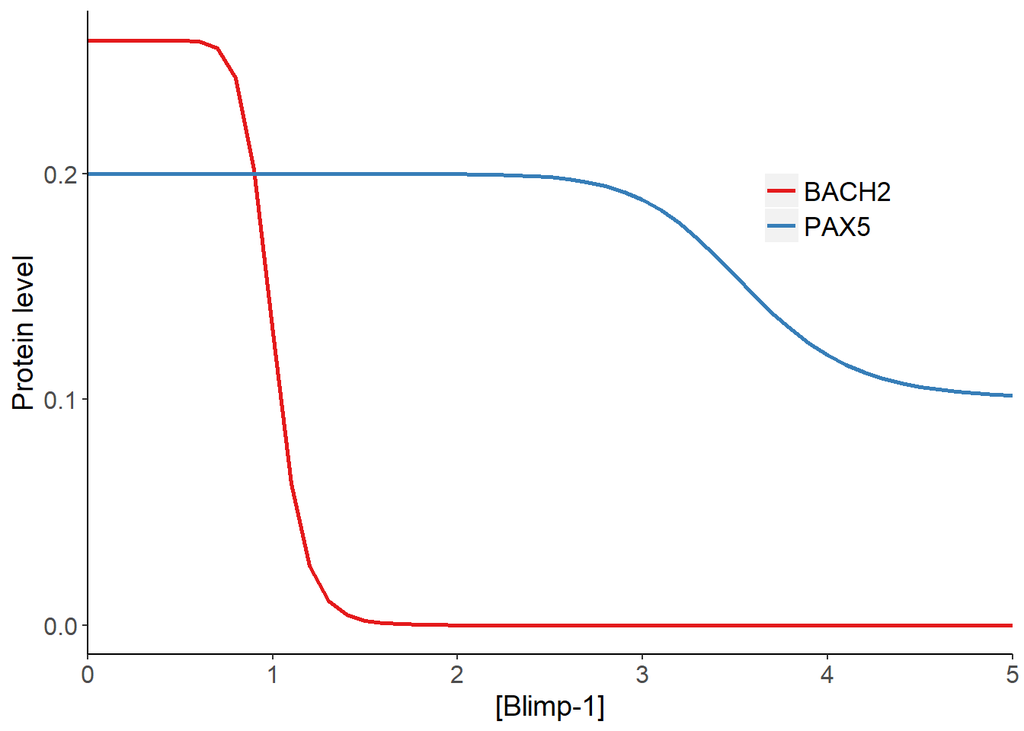

```r
library("ggplot2")
library("dplyr")
library("deSolve")
library("tidyr")
library("directlabels")

Muto1 <- function(t, y, parameters) {
  #calculates dx/dts for a GRN

  # t: time at which to evaluate derivatives
  # y: vector of system variables (c(P,B,R))
  # parameters: vector of model parameters

  PAX5 <- y[1]
  BACH2 <- y[2]

  C1  <- parameters['C1']
  C2  <- parameters['C2']
  ns  <- parameters['ns']
  e0  <- parameters['e0']
  a   <- parameters['a']
  C3  <- parameters['C3']
  C4  <- parameters['C4']
  kx <- parameters['kx']
  ns_ <- parameters['ns_']
  a1  <- parameters['a1']
  nr  <- parameters['nr']
  kh <- parameters['kh']
  b1  <- parameters['b1']
  e1  <- parameters['e1']
  BLIMP1 <- parameters['BLIMP1']

  # calculate rate of change
  dPAX5 <- C1 * (kx ^ ns / (kx ^ ns + BLIMP1 ^ ns)) + e0 - PAX5
  dBACH2 <- (C3 / (1 + C4* BLIMP1 ^ns_))*((a * 0.2 ^ nr / (kh^nr + 0.2 ^ nr)) + e1) - BACH2

  # return rate of change
  return(list(c(dPAX5, dBACH2)))
}

# run the numerical solution

parameters = c(
  C1 = 0.1,
  C2 = 2.441*10^-7,
  ns = 12,
  e0 = 0.1,
  C3 = 1,
  kx = 3.557,
  C4 = 1,
  ns_ = 12,
  a1 = 3,
  a = 1,
  kh = 0.633,
  nr = 2.4,
  b1 = 3,
  e1 = 0.2,
  BLIMP1 = 2
)

state <- c(PAX5= 1, BACH2 = 1) # starting states
initial_conditions <-  matrix(c(0, 0,
                                0.5, 0,
                                0, 0.5,
                                0.5, 0.5,
                                0.2, 0.2),
                              ncol = 2,
                              byrow = TRUE)

times <- seq(0, 100, by = 0.01)

BLIMP_vector = seq(0,5,0.1)
BACH_vector= NULL
PAX_vector= NULL
for (BLIMP1 in BLIMP_vector){

  parameters["BLIMP1"] = BLIMP1
  result <-
    ode(
      y = state,
      times = times,
      func = Muto1,
      parms = parameters
    )
  result <- data.frame(result)
  BACH_vector = append(BACH_vector, result$BACH2[9999])
  PAX_vector = append(PAX_vector, result$PAX5[9999])
}

equilibrium_plot <-  data.frame(BLIMP_vector,BACH_vector,PAX_vector)

equilibrium_plot %>%
  rename(BACH2=BACH_vector, PAX5=PAX_vector) %>%
  gather(Factor, Concentration, -BLIMP_vector) %>%
  ggplot(aes(x=BLIMP_vector, y=Concentration, color=Factor)) +
  geom_line(aes(x=BLIMP_vector, y=Concentration), cex = 1) +
  xlab("[Blimp-1]") +
  ylab("Protein level") +
  scale_color_brewer(palette = "Set1")+
  theme(panel.background = element_rect(fill = "white"),
    legend.position=c(0.8,0.7),
    axis.text=element_text(size=12),
    legend.title=element_blank(),
    axis.title=element_text(size=14),
    legend.text=element_text(size=13),
    axis.line = element_line(colour = "black"))+
  scale_x_continuous(expand = c(0, 0))
```

The graph above uses the model by Muto et al. to display differences of stable states in [Pax5] and [Bach2] with changes in [Blimp-1]. As can be seen in the graph, Bach2 decreases prior to Pax5 decrease. This phenomenom was found in in vitro cell cultures (Muto et al.). The study suggests that Bach kinetic regulate the onset of CSR as a timekeeper.Although if we analyze the model further we find that the repression of Bach2 by Blimp-1 is not supported by data, rising the question whether the model is valid.

The model for bach: $\frac{\mathrm{d}[Bach2]}{\mathrm{d}t}=\left[\frac{C_3}{1+C_4[Blimp\text{-}1]^{n_\text{s'}}}\right]\left[\frac{a_1[Pax5]}{1+b_1[Pax5]^{n_r}} + e_1 \right] - [Bach2]$ has a repression by Blimp1 in the first term of the righthand side of the equation. Muto et al. clearly state that repression by Blimp1 is not the case. If we were to change the equation to the follwoing without Blimp1 suppression: $\frac{\mathrm{d}[Bach2]}{\mathrm{d}t}=\left[\frac{a_1[Pax5]}{1+b_1[Pax5]^{n_r}} + e_1 \right] - [Bach2]$ we can again plot the changes of Pax and Bach with Blimp.

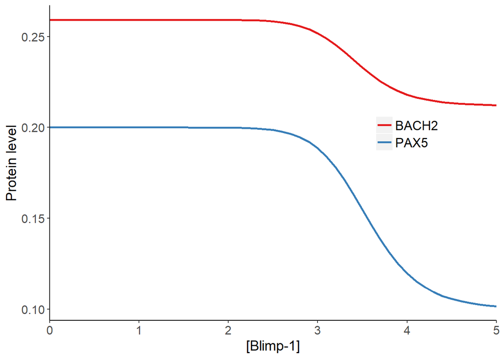

```r
library("ggplot2")
library("dplyr")
library("deSolve")
library("tidyr")

Muto1 <- function(t, y, parameters) {
  #calculates dx/dts for a GRN

  # t: time at which to evaluate derivatives
  # y: vector of system variables (c(P,B,R))
  # parameters: vector of model parameters

  PAX5 <- y[1]
  BACH2 <- y[2]

  C1  <- parameters['C1']
  C2  <- parameters['C2']
  ns  <- parameters['ns']
  e0  <- parameters['e0']

  C3  <- parameters['C3']
  C4  <- parameters['C4']
  ns_ <- parameters['ns_']
  a1  <- parameters['a1']
  nr  <- parameters['nr']
  b1  <- parameters['b1']
  e1  <- parameters['e1']
  BLIMP1 <- parameters['BLIMP1']

  # calculate rate of change
  dPAX5 <- (C1 / (1 + C2 * BLIMP1 ^ ns)) + e0 - PAX5
  dBACH2 <- ((a1 * PAX5 ^ nr / (1 + b1 * PAX5 ^ nr)) + e1) - BACH2

  # return rate of change
  return(list(c(dPAX5, dBACH2)))
}

# run the numerical solution

parameters = c(
  C1 = 0.1,
  C2 = 2.441*10^-7,
  ns = 12,
  e0 = 0.1,
  C3 = 1,
  C4 = 1,
  ns_ = 12,
  a1 = 3,
  nr = 2.4,
  b1 = 3,
  e1 = 0.2,
  BLIMP1 = 2
)

state <- c(PAX5= 1, BACH2 = 1) # starting states
initial_conditions <-  matrix(c(0, 0,
                                0.5, 0,
                                0, 0.5,
                                0.5, 0.5,
                                0.2, 0.2),
                              ncol = 2,
                              byrow = TRUE)

times <- seq(0, 100, by = 0.01)

BLIMP_vector = seq(0,5,0.1)
BACH_vector= NULL
PAX_vector= NULL
for (BLIMP1 in BLIMP_vector){

  parameters["BLIMP1"] = BLIMP1
  result <-
    ode(
      y = state,
      times = times,
      func = Muto1,
      parms = parameters
    )
  result <- data.frame(result)
  BACH_vector = append(BACH_vector, result$BACH2[9999])
  PAX_vector = append(PAX_vector, result$PAX5[9999])
}

equilibrium_plot <-  data.frame(BLIMP_vector,BACH_vector,PAX_vector)

equilibrium_plot %>%
  rename(BACH2=BACH_vector, PAX5=PAX_vector) %>%
  gather(Factor, Concentration, -BLIMP_vector) %>%
  ggplot(aes(x=BLIMP_vector, y=Concentration, color=Factor)) +
  scale_color_brewer(palette = "Set1")+
  labs(y = "Protein level", x= "[Blimp-1]",cex=5) +
  theme(legend.position=c(0.8,0.6),
        legend.title = element_blank(),
        axis.text=element_text(size=12),
        axis.title=element_text(size=14),
        axis.line = element_line(colour = "black"),
        legend.text=element_text(size=13))+
  scale_x_continuous(expand = c(0, 0)) +
  theme(panel.background = element_rect(fill = "white")) +
  geom_line(aes(x=BLIMP_vector, y=Concentration), cex = 1)
```

The model without Blimp-1 repression does not display a diference in the onset of Bach and Pax repression. Which is actually expected because Bach2 cannot change without Pax5 changing.

## Martinez + Muto

Equation 1
$$\frac{d[Pax5]}{dt}=\frac{C_1}{1+C_2[Blimp\text{-}1]^{n_s}} + e_0-[Pax5]$$
Equation 2
$$\frac{\mathrm{d}[Bach2]}{\mathrm{d}t}=\left[\frac{C_3}{1+C_4[Blimp\text{-}1]^{n_\text{s'}}}\right]\left[\frac{a_1[Pax5]}{1+b_1[Pax5]^{n_r}} + e_1 \right] - [Bach2]$$

```r
library("ggplot2")
library("dplyr")
library("deSolve")
library("grid")
library("tidyr")
library("directlabels")

Roman1 <- function(t, y, parameters) {
  #calculates dx/dts for a GRN

  # t: time at which to evaluate derivatives
  # y: vector of system variables (c(P,B,R))
  # parameters: vector of model parameters

  BLIMP1 <- y[1]
  BCL6 <- y[2]
  IRF4 <- y[3]
  PAX5 <- y[4]
  BACH2 <-y[5]

  up <- parameters['up']    # passive transcription rate
  ub <- parameters['ub']
  ur <- parameters['ur']


  op <- parameters['op']    # max induced transcription rate
  ob <- parameters['ob']
  or <- parameters['or']

  kb <- parameters['kb']    # dissociation constant
  kr <- parameters['kr']
  kp <- parameters['kp']

  ep <- parameters['ep']    # rate of degradation
  eb <- parameters['eb']
  er <- parameters['er']

  # Muto parameters
  C1  <- parameters['C1']
  C2  <- parameters['C2']
  ns  <- parameters['ns']
  e0  <- parameters['e0']

  C3  <- parameters['C3']
  C4  <- parameters['C4']
  ns_ <- parameters['ns_']
  a1  <- parameters['a1']
  nr  <- parameters['nr']
  b1  <- parameters['b1']
  e1  <- parameters['e1']


  CD40 <-2 * dnorm(t, 25, 2) * (kb ^ 2 / (kb ^ 2 + BCL6 ^ 2))
  BCR <- 20 * dnorm(t, 21, 2) * (kb ^ 2 / ( kb ^ 2 + BCL6 ^ 2))

  # calculate rate of change
  dBLIMP1 <- up + op * (kb ^ 2 / (kb ^ 2 + BACH2 ^ 2)) * (kb ^ 2 / (kb ^ 2 + BCL6 ^ 2)) + op * (IRF4 ^ 2 / (kr ^ 2 + IRF4 ^ 2)) - ep * BLIMP1
  dBCL6 <- ub + ob * (kp ^ 2 / (kp ^ 2 + BLIMP1 ^ 2)) * (kb ^ 2 / (kb ^ 2 + BCL6 ^ 2)) * (kr ^ 2 / (kr ^ 2 + IRF4 ^ 2)) - (eb + BCR) * BCL6
  dIRF4 <- ur + or * (IRF4 ^ 2 / (kr ^ 2 + IRF4 ^ 2)) + CD40 - er * IRF4
  dPAX5 <- (C1 / (1 + C2 * BLIMP1 ^ ns)) + e0 - PAX5
  dBACH2 <- (C3 / (1 + C4* BLIMP1 ^ns_))*((a1 * PAX5 ^ nr / (1 + b1 * PAX5 ^ nr)) + e1) - BACH2


  # return rate of change
  return(list(c(dBLIMP1, dBCL6, dIRF4, dPAX5, dBACH2)))
}

# run the numerical solution

parameters = c(
  up = 10 ^ -6,
  ub = 2,
  ur = 0.1,
  op = 9,
  ob = 100,       #just some parameters, no bxiggie
  or = 2.6,
  kp = 1,
  kb = 1,
  kr = 1,
  ep = 1,
  eb = 1,
  er = 1,
  BCR = 0,
  CD40 = 0,
  C1 = 0.1,
  C2 = 2* 10^-7,
  ns = 12,
  e0 = 0.1,
  C3 = 1,
  C4 = 1,
  ns_ = 2.8,
  a1 = 3,
  nr = 2.4,
  b1 = 3,
  e1 = 0.2
)

state <- c(BLIMP1 = 0.747, BCL6 = 4.7, IRF4 = 0.2, PAX5 = 0.2, BACH2 = 0.182) # starting states

times <- seq(0, 50, by = 0.01)

result <- ode(y=state, times = times, func = Roman1, parms = parameters)
result <- data.frame(result)


# plot the results

 result <- result %>%
  gather(Factor, Value, -time)
 str(result)
```

```
## 'data.frame':    25005 obs. of  3 variables:
##  $ time  : num  0 0.01 0.02 0.03 0.04 0.05 0.06 0.07 0.08 0.09 ...
##  $ Factor: chr  "BLIMP1" "BLIMP1" "BLIMP1" "BLIMP1" ...
##  $ Value : num  0.747 0.747 0.747 0.746 0.746 ...
```

```r
 result$Factor <- factor(result$Factor, levels = c("BLIMP1", "BCL6", "IRF4", "BACH2", "PAX5"))
 str(result)
```

```
## 'data.frame':    25005 obs. of  3 variables:
##  $ time  : num  0 0.01 0.02 0.03 0.04 0.05 0.06 0.07 0.08 0.09 ...
##  $ Factor: Factor w/ 5 levels "BLIMP1","BCL6",..: 1 1 1 1 1 1 1 1 1 1 ...
##  $ Value : num  0.747 0.747 0.747 0.746 0.746 ...
```

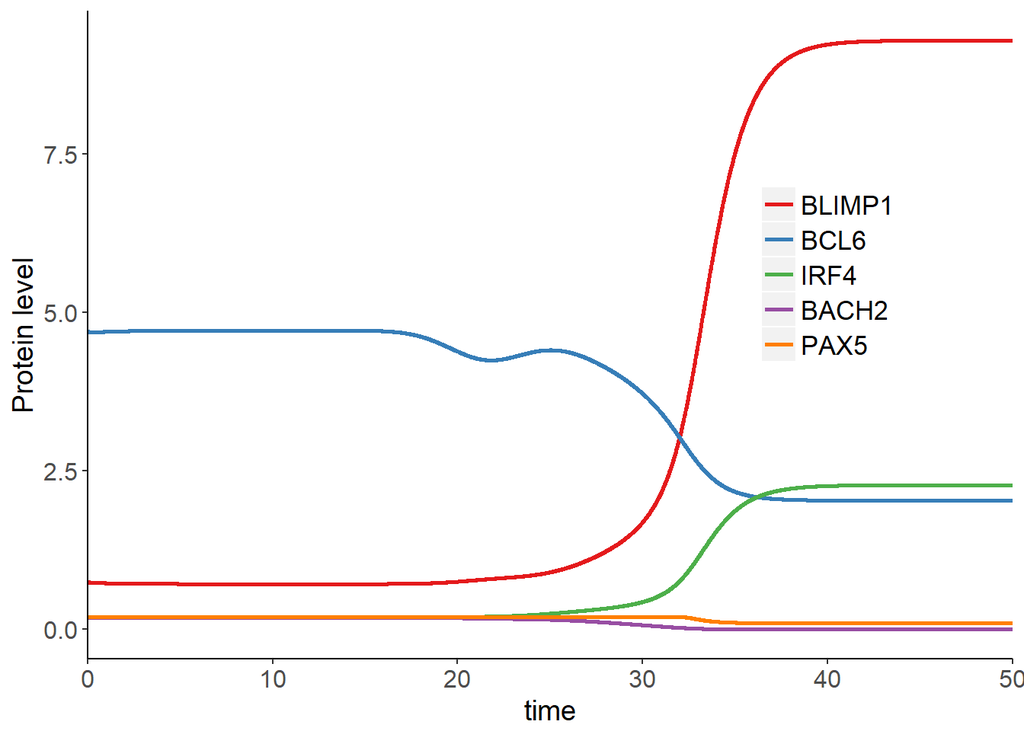

```r
result %>%
  ggplot(aes(x = time, y = Value, fill = Factor, color = Factor)) +
  geom_line(aes(x = time, y = Value), cex = 1) +
  scale_color_brewer(palette = "Set1") +
  scale_x_continuous(expand = c(0, 0)) +
  labs(y = "Protein level", x= "time") +
  theme(legend.position=c(0.8,0.6),
        legend.title = element_blank(),
        axis.text=element_text(size=12),
        axis.title=element_text(size=14),
        panel.background = element_rect(fill = "white"),
        axis.line = element_line(colour = "black"),
        legend.text=element_text(size=13))
```

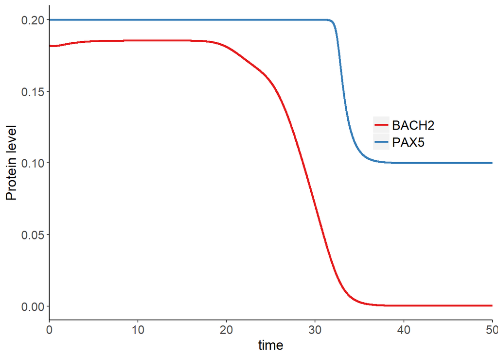

```r
result <- result %>%
  filter(Factor == "BACH2" | Factor == "PAX5")


result %>%
  ggplot(aes(x = time, y = Value,fill = Factor, color = Factor)) +
  scale_color_brewer(palette = "Set1") +
  geom_line(aes(x = time, y = Value), cex = 1) +
  labs(y = "Protein level", x= "time") +
  scale_x_continuous(expand = c(0, 0)) +
  theme(legend.position=c(0.8,0.6),
        legend.title = element_blank(),
        axis.text=element_text(size=12),
        panel.background = element_rect(fill = "white"),
        axis.title=element_text(size=14),
        axis.line = element_line(colour = "black"),
        legend.text=element_text(size=13))
```

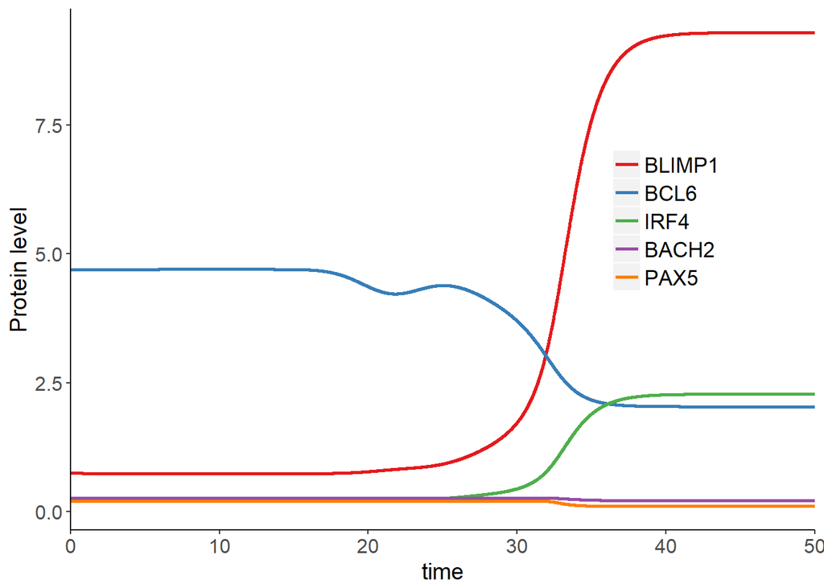

```r
library("ggplot2")
library("dplyr")
library("deSolve")
library("grid")
library("tidyr")
library("directlabels")

Roman1 <- function(t, y, parameters) {
  #calculates dx/dts for a GRN

  # t: time at which to evaluate derivatives
  # y: vector of system variables (c(P,B,R))
  # parameters: vector of model parameters

  BLIMP1 <- y[1]
  BCL6 <- y[2]
  IRF4 <- y[3]
  PAX5 <- y[4]
  BACH2 <-y[5]

  up <- parameters['up']    # passive transcription rate
  ub <- parameters['ub']
  ur <- parameters['ur']


  op <- parameters['op']    # max induced transcription rate
  ob <- parameters['ob']
  or <- parameters['or']

  kb <- parameters['kb']    # dissociation constant
  kr <- parameters['kr']
  kp <- parameters['kp']

  ep <- parameters['ep']    # rate of degradation
  eb <- parameters['eb']
  er <- parameters['er']

  # Muto parameters
  C1  <- parameters['C1']
  C2  <- parameters['C2']
  ns  <- parameters['ns']
  e0  <- parameters['e0']

  C3  <- parameters['C3']
  C4  <- parameters['C4']
  ns_ <- parameters['ns_']
  a1  <- parameters['a1']
  nr  <- parameters['nr']
  b1  <- parameters['b1']
  e1  <- parameters['e1']


  CD40 <-2 * dnorm(t, 25, 2) * (kb ^ 2 / (kb ^ 2 + BCL6 ^ 2))
  BCR <- 20 * dnorm(t, 21, 2) * (kb ^ 2 / ( kb ^ 2 + BCL6 ^ 2))

  # calculate rate of change
  dBLIMP1 <- up + op * (kb ^ 2 / (kb ^ 2 + BCL6 ^ 2)) + op * (IRF4 ^ 2 / (kr ^ 2 + IRF4 ^ 2)) - ep * BLIMP1
  dBCL6 <- ub + ob * (kp ^ 2 / (kp ^ 2 + BLIMP1 ^ 2)) * (kb ^ 2 / (kb ^ 2 + BCL6 ^ 2)) * (kr ^ 2 / (kr ^ 2 + IRF4 ^ 2)) - (eb + BCR) * BCL6
  dIRF4 <- ur + or * (IRF4 ^ 2 / (kr ^ 2 + IRF4 ^ 2)) + CD40 - er * IRF4
  dPAX5 <- (C1 / (1 + C2 * BLIMP1 ^ ns)) + e0 - PAX5
  dBACH2 <- ((a1 * PAX5 ^ nr / (1 + b1 * PAX5 ^ nr)) + e1) - BACH2


  # return rate of change
  return(list(c(dBLIMP1, dBCL6, dIRF4, dPAX5, dBACH2)))
}

# run the numerical solution

parameters = c(
  up = 10 ^ -6,
  ub = 2,
  ur = 0.1,
  op = 9,
  ob = 100,       #just some parameters, no bxiggie
  or = 2.6,
  kp = 1,
  kb = 1,
  kr = 1,
  ep = 1,
  eb = 1,
  er = 1,
  BCR = 0,
  CD40 = 0,
  C1 = 0.1,
  C2 = 2* 10^-7,
  ns = 12,
  e0 = 0.1,
  C3 = 1,
  C4 = 1,
  ns_ = 2.8,
  a1 = 3,
  nr = 2.4,
  b1 = 3,
  e1 = 0.2
)

state <- c(BLIMP1 = 0.747, BCL6 = 4.7, IRF4 = 0.2, PAX5 = 0.2, BACH2 = 0.26) # starting states

times <- seq(0, 50, by = 0.01)

result <- ode(y=state, times = times, func = Roman1, parms = parameters)
result <- data.frame(result)

result <- mutate(result, BCR = dnorm(time, 20, 2) * 20 * (1 ^ 2 / (1 ^ 2 + BCL6 ^ 2))) %>%
  mutate(CD40 = dnorm(time, 30, 2) * 20 * (1 ^ 2 / (1 ^ 2 + BCL6 ^ 2)))


# plot the results

 result <- result %>%
  gather(Factor, Value, -time) %>%
   filter(Factor != "BCR" & Factor != "CD40")

  result$Factor <- factor(result$Factor, levels = c("BLIMP1", "BCL6", "IRF4", "BACH2", "PAX5"))

result %>%
  ggplot(aes(x = time, y = Value, color = Factor)) +
  geom_line(aes(x = time, y = Value), cex = 1) +
  scale_color_brewer(palette = "Set1")+
  labs(y = "Protein level", x= "time",cex=5) +
  theme(legend.position=c(0.8,0.6),
        legend.title = element_blank(),
        axis.text=element_text(size=12),
        axis.title=element_text(size=14),
        axis.line = element_line(colour = "black"),
        legend.text=element_text(size=13))+
  scale_x_continuous(expand = c(0, 0)) +
  theme(panel.background = element_rect(fill = "white"))
```

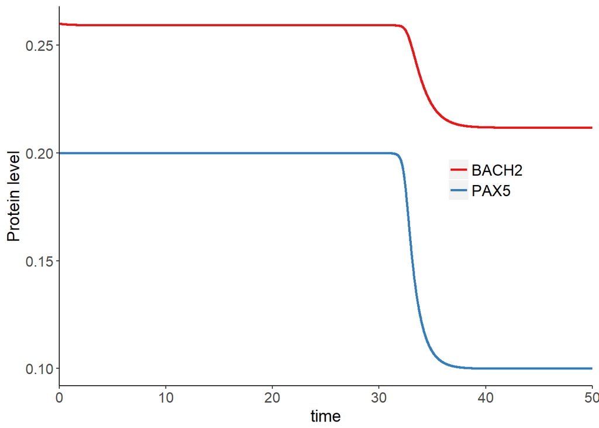

```r
result <- result %>%
  filter(Factor == "PAX5" | Factor == "BACH2")


result %>%
  ggplot(aes(x = time, y = Value, color = Factor)) +
  geom_line(aes(x = time, y = Value), cex = 1) +
  scale_color_brewer(palette = "Set1")+
  labs(y = "Protein level", x= "time") +
  theme(legend.position=c(0.8,0.55),
        legend.title = element_blank(),
        axis.text=element_text(size=12),
        axis.title=element_text(size=14),
        axis.line = element_line(colour = "black"),
        legend.text=element_text(size=13))+
  scale_x_continuous(expand = c(0, 0)) +
  theme(panel.background = element_rect(fill = "white"))
```

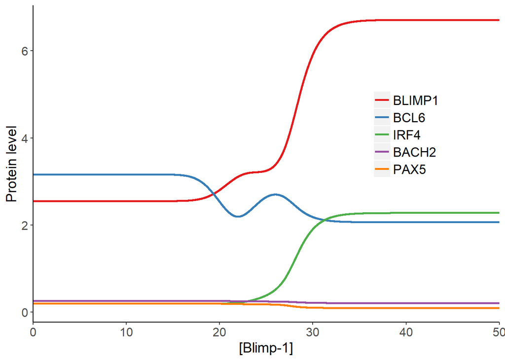

```r
library("ggplot2")
library("dplyr")
library("deSolve")
library("grid")
library("tidyr")
library("directlabels")

Roman1 <- function(t, y, parameters) {
  #calculates dx/dts for a GRN

  # t: time at which to evaluate derivatives
  # y: vector of system variables (c(P,B,R))
  # parameters: vector of model parameters

  BLIMP1 <- y[1]
  BCL6 <- y[2]
  IRF4 <- y[3]
  PAX5 <- y[4]
  BACH2 <-y[5]

  up <- parameters['up']    # passive transcription rate
  ub <- parameters['ub']
  ur <- parameters['ur']


  op <- parameters['op']    # max induced transcription rate
  ob <- parameters['ob']
  or <- parameters['or']

  kb <- parameters['kb']    # dissociation constant
  kr <- parameters['kr']
  kp <- parameters['kp']

  ep <- parameters['ep']    # rate of degradation
  eb <- parameters['eb']
  er <- parameters['er']

  # Muto parameters
  C1  <- parameters['C1']
  C2  <- parameters['C2']
  ns  <- parameters['ns']
  e0  <- parameters['e0']

  C3  <- parameters['C3']
  C4  <- parameters['C4']
  ns_ <- parameters['ns_']
  a1  <- parameters['a1']
  nr  <- parameters['nr']
  b1  <- parameters['b1']
  e1  <- parameters['e1']


  CD40 <- 2 * dnorm(t, 25, 2) * (kb ^ 2 / (kb ^ 2 + BCL6 ^ 2))
  BCR <- 20 * dnorm(t, 21, 2) * (kb ^ 2 / ( kb ^ 2 + BCL6 ^ 2))

  # calculate rate of change
  dBLIMP1 <- up + op * (kb ^ 2 / (kb ^ 2 + (BACH2*BCL6) ^ 2)) + op * (IRF4 ^ 2 / (kr ^ 2 + IRF4 ^ 2)) - ep * BLIMP1
  dBCL6 <- ub + ob * (kp ^ 2 / (kp ^ 2 + BLIMP1 ^ 2)) * (kb ^ 2 / (kb ^ 2 + BCL6 ^ 2)) * (kr ^ 2 / (kr ^ 2 + IRF4 ^ 2)) - (eb + BCR) * BCL6
  dIRF4 <- ur + or * (IRF4 ^ 2 / (kr ^ 2 + IRF4 ^ 2)) + CD40 - er * IRF4
  dPAX5 <- (C1 / (1 + C2 * BLIMP1 ^ ns)) + e0 - PAX5
  dBACH2 <- ((a1 * PAX5 ^ nr / (1 + b1 * PAX5 ^ nr)) + e1) - BACH2


  # return rate of change
  return(list(c(dBLIMP1, dBCL6, dIRF4, dPAX5, dBACH2)))
}

# run the numerical solution

parameters = c(
  up = 10 ^ -6,
  ub = 2,
  ur = 0.1,
  op = 4,
  ob = 100,       #just some parameters, no bxiggie
  or = 2.6,
  kp = 1,
  kb = 1,
  kr = 1,
  ep = 1,
  eb = 1,
  er = 1,
  BCR = 0,
  CD40 = 0,
  C1 = 0.1,
  C2 = 2* 10^-7,
  ns = 12,
  e0 = 0.1,
  C3 = 1,
  C4 = 1,
  ns_ = 2.8,
  a1 = 3,
  nr = 2.4,
  b1 = 3,
  e1 = 0.2
)

state <- c(BLIMP1 = 2.55, BCL6 = 3.16, IRF4 = 0.2, PAX5 = 0.2, BACH2 = 0.258) # starting states

times <- seq(0, 50, by = 0.01)

result <- ode(y=state, times = times, func = Roman1, parms = parameters)
result <- data.frame(result)

result <- mutate(result, BCR = dnorm(time, 20, 2) * 20 * (1 ^ 2 / (1 ^ 2 + BCL6 ^ 2))) %>%
  mutate(CD40 = dnorm(time, 30, 2) * 20 * (1 ^ 2 / (1 ^ 2 + BCL6 ^ 2)))


# plot the results

 result <- result %>%
  gather(Factor, Value, -time) %>%
   filter(Factor != "BCR" & Factor != "CD40")

 result$Factor <- factor(result$Factor, levels = c("BLIMP1", "BCL6", "IRF4", "BACH2", "PAX5"))

result %>%
  ggplot(aes(x = time, y = Value, color = Factor)) +
  geom_line(aes(x = time, y = Value), cex = 1) +
  scale_color_brewer(palette = "Set1")+
  labs(y = "Protein level", x= "[Blimp-1]",cex=5) +
  theme(legend.position=c(0.8,0.6),
        legend.title = element_blank(),
        axis.text=element_text(size=12),
        axis.title=element_text(size=14),
        axis.line = element_line(colour = "black"),
        legend.text=element_text(size=13))+
  scale_x_continuous(expand = c(0, 0)) +
  theme(panel.background = element_rect(fill = "white"))
```

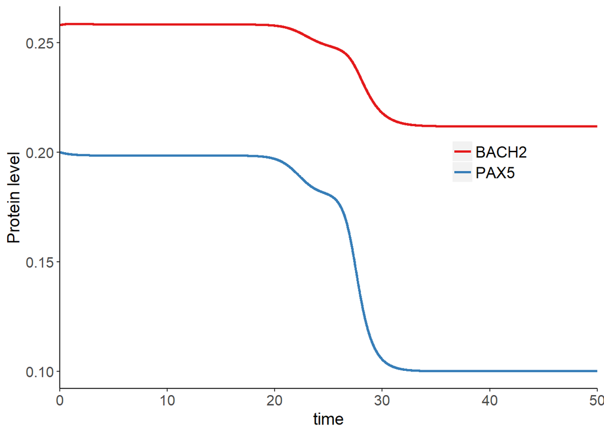

```r
results <- result %>%
  filter(Factor == "BACH2" | Factor == "PAX5")


results %>%
  ggplot(aes(x = time, y = Value, color = Factor)) +
  geom_line(aes(x = time, y = Value), cex = 1) +
  scale_color_brewer(palette = "Set1")+
  labs(y = "Protein level", x= "time") +
  theme(legend.position=c(0.8,0.6),
        legend.title = element_blank(),
        axis.text=element_text(size=12),
        axis.title=element_text(size=14),
        axis.line = element_line(colour = "black"),
        legend.text=element_text(size=13))+
  scale_x_continuous(expand = c(0, 0)) +
  theme(panel.background = element_rect(fill = "white"))
```

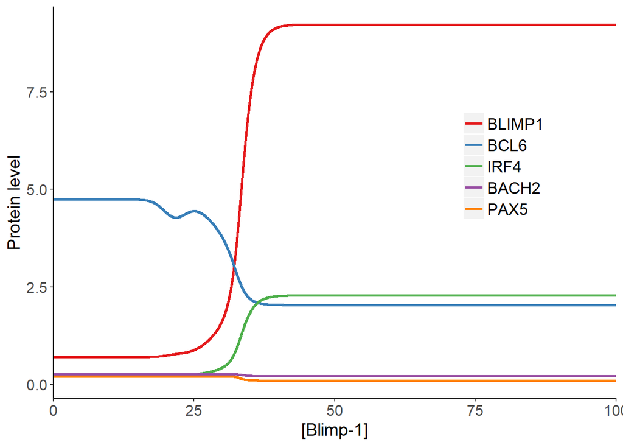

```r
library("ggplot2")
library("dplyr")
library("deSolve")
library("grid")
library("tidyr")
library("directlabels")

Roman1 <- function(t, y, parameters) {
  #calculates dx/dts for a GRN

  # t: time at which to evaluate derivatives
  # y: vector of system variables (c(P,B,R))
  # parameters: vector of model parameters

  BLIMP1 <- y[1]
  BCL6 <- y[2]
  IRF4 <- y[3]
  PAX5 <- y[4]
  BACH2 <-y[5]

  up <- parameters['up']    # passive transcription rate
  ub <- parameters['ub']
  ur <- parameters['ur']


  op <- parameters['op']    # max induced transcription rate
  ob <- parameters['ob']
  or <- parameters['or']

  kb <- parameters['kb']    # dissociation constant
  kr <- parameters['kr']
  kp <- parameters['kp']

  ep <- parameters['ep']    # rate of degradation
  eb <- parameters['eb']
  er <- parameters['er']

  # Muto parameters
  C1  <- parameters['C1']
  C2  <- parameters['C2']
  ns  <- parameters['ns']
  e0  <- parameters['e0']

  C3  <- parameters['C3']
  C4  <- parameters['C4']
  ns_ <- parameters['ns_']
  a1  <- parameters['a1']
  nr  <- parameters['nr']
  b1  <- parameters['b1']
  e1  <- parameters['e1']


  CD40 <- 2 * dnorm(t, 25, 2) * (kb ^ 2 / (kb ^ 2 + BCL6 ^ 2))
  BCR <- 20 * dnorm(t, 21, 2) * (kb ^ 2 / ( kb ^ 2 + BCL6 ^ 2))

  # calculate rate of change
  dBLIMP1 <- up + op * (kb ^ 2 / (kb ^ 2 + BACH2 ^ 2)) * (kb ^ 2 / (kb ^ 2 + BCL6 ^ 2)) + op * (IRF4 ^ 2 / (kr ^ 2 + IRF4 ^ 2)) - ep * BLIMP1
  dBCL6 <- ub + ob * (kp ^ 2 / (kp ^ 2 + BLIMP1 ^ 2)) * (kb ^ 2 / (kb ^ 2 + BCL6 ^ 2)) * (kr ^ 2 / (kr ^ 2 + IRF4 ^ 2)) - (eb + BCR) * BCL6
  dIRF4 <- ur + or * (IRF4 ^ 2 / (kr ^ 2 + IRF4 ^ 2)) + CD40 - er * IRF4
  dPAX5 <- (C1 / (1 + C2 * BLIMP1 ^ ns)) + e0 - PAX5
  dBACH2 <- ((a1 * PAX5 ^ nr / (1 + b1 * PAX5 ^ nr)) + e1) - BACH2


  # return rate of change
  return(list(c(dBLIMP1, dBCL6, dIRF4, dPAX5, dBACH2)))
}

# run the numerical solution

parameters = c(
  up = 10 ^ -6,
  ub = 2,
  ur = 0.1,
  op = 9,
  ob = 100,       #just some parameters, no bxiggie
  or = 2.6,
  kp = 1,
  kb = 1,
  kr = 1,
  ep = 1,
  eb = 1,
  er = 1,
  BCR = 0,
  CD40 = 0,
  C1 = 0.1,
  C2 = 2* 10^-7,
  ns = 12,
  e0 = 0.1,
  C3 = 1,
  C4 = 1,
  ns_ = 2.8,
  a1 = 3,
  nr = 2.4,
  b1 = 3,
  e1 = 0.2
)

state <- c(BLIMP1 = 0.7, BCL6 = 4.74, IRF4 = 0.2, PAX5 = 0.2, BACH2 = 0.259) # starting states

times <- seq(0, 100, by = 0.01)

result <- ode(y=state, times = times, func = Roman1, parms = parameters)
result <- data.frame(result)

result <- mutate(result, BCR = dnorm(time, 20, 2) * 20 * (1 ^ 2 / (1 ^ 2 + BCL6 ^ 2))) %>%
  mutate(CD40 = dnorm(time, 30, 2) * 20 * (1 ^ 2 / (1 ^ 2 + BCL6 ^ 2)))


# plot the results

 result <- result %>%
  gather(Factor, Value, -time) %>%
   filter(Factor != "BCR" & Factor != "CD40")
   #filter(Factor == "PAX5" | Factor == "BACH2")

 result$Factor <- factor(result$Factor, levels = c("BLIMP1", "BCL6", "IRF4", "BACH2", "PAX5"))

result %>%
  ggplot(aes(x = time, y = Value, color = Factor)) +
  geom_line(aes(x = time, y = Value), cex = 1) +
  scale_color_brewer(palette = "Set1")+
  labs(y = "Protein level", x= "[Blimp-1]",cex=5) +
  theme(legend.position=c(0.8,0.6),
        legend.title = element_blank(),
        axis.text=element_text(size=12),
        axis.title=element_text(size=14),
        axis.line = element_line(colour = "black"),
        legend.text=element_text(size=13))+
  scale_x_continuous(expand = c(0, 0)) +
  theme(panel.background = element_rect(fill = "white"))
```

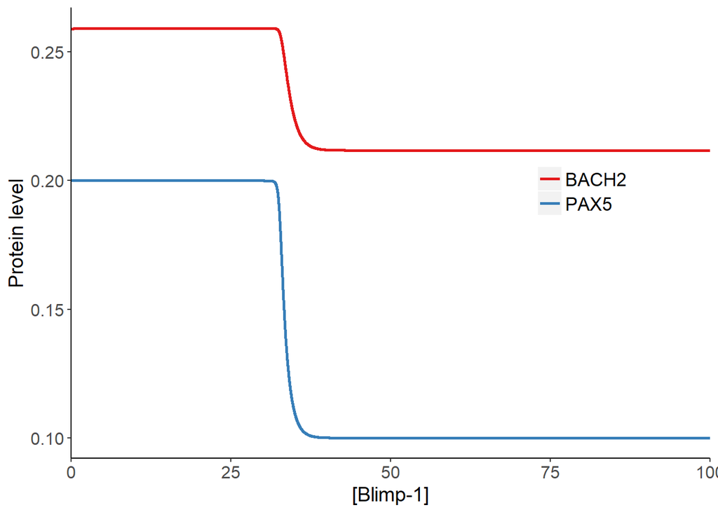

```r
results <- result %>%
  filter(Factor == "PAX5" | Factor == "BACH2")


results %>%
  ggplot(aes(x = time, y = Value, color = Factor)) +
  geom_line(aes(x = time, y = Value), cex = 1) +
  scale_color_brewer(palette = "Set1")+
  labs(y = "Protein level", x= "[Blimp-1]",cex=5) +
  theme(legend.position=c(0.8,0.6),
        legend.title = element_blank(),
        axis.text=element_text(size=12),
        axis.title=element_text(size=14),
        axis.line = element_line(colour = "black"),
        legend.text=element_text(size=13))+
  scale_x_continuous(expand = c(0, 0)) +
  theme(panel.background = element_rect(fill = "white"))
```